# Project-3-stacked

George Paul, Alec Behrendt, Noah Bean, Jeff Fong

2023-03-29

# Problem Statement

We are assuming the role of a consulting firm, hired by a company to analyze their attrition data. The company’s executives would like to be able to predict which employees will choose to leave the company, ideally for two reasons: retaining high-performing employees, and letting low-performing employees quit rather than offering a severance package. Our task is to build this model, and the company has provided us with data on employees, including both employees that have left the company and employees that have not left. We are given information on employees’ personal lives, such as age, gender, relationship status, as well as information about their job satisfaction. As for job satisfaction, we have information on pay, raises, as well as survey responses about feelings about job involvement and job/environment satisfaction. We will proceed by fitting several models and predicting onto a test set, and using these outputs as predictors for our final stacked models. Our success will be measured by analyzing the kappa value, to see if we truly can predict which employees will stay or leave, and also by estimating the profitability of this practice.

# Libraries

```r
library(class)
library(janitor)
library(neuralnet)
library(caret)
library(kernlab)
library(C50)
library(randomForest)
```

# Combined Data Frame

Below we read in several csv files, which are the outputs of our first-levels fitted models. We will combine these predictions together to make our final data frame, and these predictions will now be used as input variables to make our final models.

```r
test.labels <- read.csv("test.labels.csv")
ann.preds <- read.csv("ann.preds.csv")
tree.preds <- read.csv("decision.tree.csv")
knn.preds <- read.csv("employees.knn.csv")
logreg.preds <- read.csv("logreg.preds.csv")
rm.preds <- read.csv("rm.preds.csv")
svm.preds <- read.csv("svm.preds.csv")

combined.df <- data.frame(Attrition = test.labels[,2],
                          ann = ann.preds[,2],
                          tree = tree.preds[,2],
                          knn = knn.preds[,2],
                          logreg = logreg.preds[,2],
                          rm = rm.preds[,2],
                          svm = svm.preds[,2])

combined.df$Attrition <- as.factor(combined.df$Attrition)
combined.df$tree <- as.factor(combined.df$tree)
combined.df$rm <- as.factor(combined.df$rm)
combined.df$svm <- as.factor(combined.df$svm)

combined.df <- clean_names(combined.df)
kappa.table <- read.csv("kappa.table.csv")
kappa.table$X <- NULL
```

# New Train/Test

```r
n2 <- nrow(combined.df)
set.seed(0)
idx2 <- sample(n2, n2*.7)

final.train <- combined.df[idx2,]
final.test <- combined.df[-idx2,]
```

# Fit Final Models

## Random Forest

```r
set.seed(1)
final.rf <- randomForest(attrition ~ ., data = final.train)
final.rf.preds <- predict(final.rf, final.test)
confusionMatrix(final.rf.preds, final.test$attrition)
```

```
## Confusion Matrix and Statistics
##
##           Reference
## Prediction  No Yes
##        No  183  29
##        Yes   2   7
##
##                Accuracy : 0.8597
##                  95% CI : (0.8068, 0.9027)
##     No Information Rate : 0.8371
##     P-Value [Acc > NIR] : 0.2081
##
##                   Kappa : 0.2631
##
##  Mcnemar's Test P-Value : 3.016e-06
##
##             Sensitivity : 0.9892
##             Specificity : 0.1944
##          Pos Pred Value : 0.8632
##          Neg Pred Value : 0.7778
##              Prevalence : 0.8371
##          Detection Rate : 0.8281
##    Detection Prevalence : 0.9593
##       Balanced Accuracy : 0.5918
##
##        'Positive' Class : No
##
```

```r
final.rf.kappa <- confusionMatrix(final.rf.preds, final.test$attrition)$overall[2]
```

## Boosted Decision Tree

```r
ctrl <- trainControl(method = "cv", number = 10,
                     selectionFunction = "oneSE")

grid_tree <- expand.grid(.trials = c(1,5,10),
                         .model = "tree",
                         .winnow = "FALSE")
final.tree <- train(attrition ~ ., data = final.train, method = "C5.0",
           metric = "Kappa",
           trControl = ctrl,
           tuneGrid = grid_tree)
final.tree
```

```
## C5.0
##
## 514 samples
##   6 predictor
##   2 classes: 'No', 'Yes'
##
## No pre-processing
## Resampling: Cross-Validated (10 fold)
## Summary of sample sizes: 463, 462, 462, 462, 463, 462, ...
## Resampling results across tuning parameters:
##
##   trials  Accuracy   Kappa
##    1      0.8735294  0.3900463
##    5      0.8716063  0.3845151
##   10      0.8716063  0.3845151
##
## Tuning parameter 'model' was held constant at a value of tree
## Tuning
##  parameter 'winnow' was held constant at a value of FALSE
## Kappa was used to select the optimal model using  the one SE rule.
## The final values used for the model were trials = 1, model = tree and winnow
##  = FALSE.
```

```r
final.tree.preds <- predict(final.tree, final.test)
confusionMatrix(final.tree.preds, final.test$attrition)
```

```
## Confusion Matrix and Statistics
##
##           Reference
## Prediction  No Yes
##        No  180  25
##        Yes   5  11
##
##                Accuracy : 0.8643
##                  95% CI : (0.8119, 0.9065)
##     No Information Rate : 0.8371
##     P-Value [Acc > NIR] : 0.1580295
##
##                   Kappa : 0.3588
##
##  Mcnemar's Test P-Value : 0.0005226
##
##             Sensitivity : 0.9730
##             Specificity : 0.3056
##          Pos Pred Value : 0.8780
##          Neg Pred Value : 0.6875
##              Prevalence : 0.8371
##          Detection Rate : 0.8145
##    Detection Prevalence : 0.9276
##       Balanced Accuracy : 0.6393
##
##        'Positive' Class : No
##
```

```r
final.tree.kappa <- confusionMatrix(final.tree.preds, final.test$attrition)$overall[2]
```

# Plot of Kappa Values

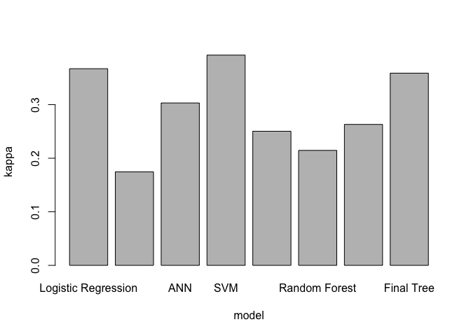

```r
kappa.table[7,1] <- "Final RF"
kappa.table[7,2] <- final.rf.kappa
kappa.table[8,1] <- "Final Tree"
kappa.table[8,2] <- final.tree.kappa

barplot(kappa.table$kappa, names.arg = kappa.table$model, xlab = "model", ylab = "kappa")
```

# Summary of Results

## Identification of Significant Predictors

By looking at models that include some sort of variable importance, we can determine which variables are the most predictive for employee attrition. The first level models we ran that will best showcase the significant variables are logistic regression and random forest. For logistic regression, we will look at the p-values of variables (after backward step selection). For the random forest, we will look at the variable importance plot. The logistic regression summary:

```
##
## Call:
## glm(formula = Attrition ~ Age + BusinessTravel + DistanceFromHome +
##     EnvironmentSatisfaction + Gender + JobInvolvement + JobRole +
##     JobSatisfaction + MaritalStatus + NumCompaniesWorked + OverTime +
##     RelationshipSatisfaction + TotalWorkingYears + TrainingTimesLastYear +
##     WorkLifeBalance + YearsAtCompany + YearsInCurrentRole + YearsSinceLastPromotion +
##     YearsWithCurrManager, family = "binomial", data = employees.train)
##
## Deviance Residuals:
##     Min       1Q   Median       3Q      Max
## -1.8252  -0.4480  -0.1957  -0.0574   3.4305
##
## Coefficients:
##                                 Estimate Std. Error z value Pr(>|z|)
## (Intercept)                      -3.3044     1.2649  -2.612 0.008992 **
## Age                              -1.4811     0.8413  -1.761 0.078305 .
## BusinessTravelTravel_Frequently   2.0499     0.6181   3.317 0.000911 ***
## BusinessTravelTravel_Rarely       1.6356     0.5791   2.824 0.004739 **
## DistanceFromHome                  2.0356     0.4546   4.478 7.54e-06 ***
## EnvironmentSatisfaction          -1.0632     0.3618  -2.939 0.003294 **
## GenderMale                        0.6764     0.2838   2.383 0.017173 *
## JobInvolvement                   -2.4747     0.5543  -4.464 8.03e-06 ***
## JobRoleHuman Resources            2.2835     1.0172   2.245 0.024771 *
## JobRoleLaboratory Technician      2.6109     0.8469   3.083 0.002049 **
## JobRoleManager                    0.6754     1.1588   0.583 0.560007
## JobRoleManufacturing Director     1.1026     0.9513   1.159 0.246427
## JobRoleResearch Director          0.9205     1.3436   0.685 0.493264
## JobRoleResearch Scientist         1.2824     0.8570   1.496 0.134546
## JobRoleSales Executive            2.1432     0.8314   2.578 0.009946 **
## JobRoleSales Representative       3.2710     0.9259   3.533 0.000411 ***
## JobSatisfaction                  -1.2035     0.3587  -3.355 0.000793 ***
## MaritalStatusMarried              0.7463     0.4037   1.849 0.064495 .
## MaritalStatusSingle               1.9102     0.4213   4.534 5.79e-06 ***
## NumCompaniesWorked                2.3882     0.5214   4.580 4.64e-06 ***
## OverTimeYes                       1.9532     0.2954   6.611 3.81e-11 ***
## RelationshipSatisfaction         -0.6224     0.3745  -1.662 0.096545 .
## TotalWorkingYears                -4.9908     1.8001  -2.772 0.005563 **
## TrainingTimesLastYear            -1.3091     0.6517  -2.009 0.044575 *
## WorkLifeBalance                  -1.1679     0.5564  -2.099 0.035814 *
## YearsAtCompany                    7.4641     2.3841   3.131 0.001744 **
## YearsInCurrentRole               -3.6115     1.2358  -2.923 0.003472 **
## YearsSinceLastPromotion           2.7018     0.8983   3.008 0.002633 **
## YearsWithCurrManager             -1.8795     1.1475  -1.638 0.101444
## ---
## Signif. codes:  0 '***' 0.001 '**' 0.01 '*' 0.05 '.' 0.1 ' ' 1
##
## (Dispersion parameter for binomial family taken to be 1)
##
##     Null deviance: 657.47  on 734  degrees of freedom
## Residual deviance: 392.83  on 706  degrees of freedom
## AIC: 450.83
##
## Number of Fisher Scoring iterations: 7
```

And now the random forest variable importance plot:

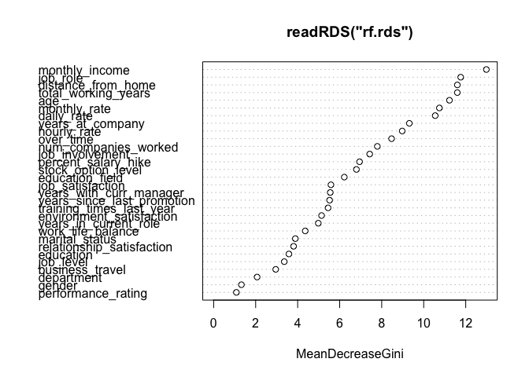

## Clustering Results

We ran the clustering algorithms in the dataset, and we found the optimal number of clusters was 3. We then created a final cluster assignment using k-means clustering with k = 3. Below shows the average attrition rate by cluster:

```
##   clusters attrition_yes
## 1        1     0.1416016
## 2        2     0.1331058
## 3        3     0.3464052
```

There appears to be one cluster with significantly higher attrition rates. Based on looking at the centers of the 3 clusters, we found the following attributes to be true of the cluster with the highest attrition rate:

- Younger
- Fewer Years in Current Role
- Unmarried
- More sales representatives
- Fewer total working years
- Fewer Years at Company

While the results of clustering seemed promise at first, we are hesitant to use clusters as a prediction rule for the following two reasons:

- These variables are mostly correlated. Younger employees would naturally have had fewer total working years, fewer years at company, be unmarried, etc.
- These variables are largely similar to the variables our models used to make predictions. Using these clusters wouldn’t add anything to the models we already built.

# Estimating Financial Impact

Once again, here is the final confusion matrix:

```
## Confusion Matrix and Statistics
##
##           Reference
## Prediction  No Yes
##        No  180  25
##        Yes   5  11
##
##                Accuracy : 0.8643
##                  95% CI : (0.8119, 0.9065)
##     No Information Rate : 0.8371
##     P-Value [Acc > NIR] : 0.1580295
##
##                   Kappa : 0.3588
##
##  Mcnemar's Test P-Value : 0.0005226
##
##             Sensitivity : 0.9730
##             Specificity : 0.3056
##          Pos Pred Value : 0.8780
##          Neg Pred Value : 0.6875
##              Prevalence : 0.8371
##          Detection Rate : 0.8145
##    Detection Prevalence : 0.9276
##       Balanced Accuracy : 0.6393
##
##        'Positive' Class : No
##
```

We correctly predict 11 employees to leave, have 5 employees we predict to leave that do not, and we have 25 employees that leave which we did not predict to leave. In other words, 11 of the 16 employees we predict to leave actually leave, but we only predict 11 of the 36 employees that actually leave. We are facing some errors in our modeling, and we should address if this prevents our modeling from creating profit for the company. Below are some facts/assumptions we will use:

- A typical severance package is 2-4 weeks per year worked, we will assume 3
- We will use the average salary and the average number of years at the company
- Median monthly salary at the company is 4919 and median number of years is 5
- We will assume that the true positives are employees that we would have fired anyway. Below is the calculation of the amount of money saved by not paying severance:

```r
# Number of employees * number of years worked * 3 weeks per year worked * monthly salary
# * 12 months per year / 52 weeks per year
saved_money_per_quitter <- 5*3*4919*12/52
saved_money <- 11*saved_money_per_quitter
saved_money
```

```
## [1] 187300.4
```

This is a significant amount of money saved for the company, but we should also consider the opportunity cost of the employees we incorrectly predicted. We have figured that we do not need to consider the cost of false negatives, because an employee unexpectedly quitting is not a new cost associated with this method, but a cost that always exists. From our confusion matrix, we have an effective probability that an employee we predict to leave will actually leave or not. Below is the expected cash value of letting an employee leave instead of firing them based on savings on severance

```r
#Saved money per quitter multiplied by probability a positive prediction is true
expected_value <- saved_money_per_quitter*(11/16)
expected_value
```

```
## [1] 11706.27
```

Each time we predict an undesired employee to leave, we can expect to save $11,706. However, we need to consider the opportunity cost of allowing an undesired employee to stay when we normally would have fired them. This is a difficult amount to predict, but we can easily calculate the breakeven cost:

```r
# Breakeven cost * Probability of false positive = Expected value of positive prediction
# Breakeven cost = Expected value of positve prediction / probability of false positive
expected_value / (5/16)
```

```
## [1] 37460.08
```

As long as the company is losing less than $37,460 on each undesirable employee that they are choosing not to fire, this method is profitable. Although we do not have an estimate for the cost of keeping an undesirable employee, we can say with some confidence that an individual employee is not causing such a large amount in losses for the company, so we can conclude that our modeling is a profitable process for the company.